# credit card 1

### Importing Basic Libraries and Dataset

**About the Dataset In recent years, the credit card issuers in Taiwan faced the cash and credit card debt crisis and the delinquency is expected to peak in the third quarter of 2006 (Chou,2006). In order to increase market share, card-issuing banks in Taiwan over-issued cash and credit cards to unqualified applicants. At the same time, most cardholders, irrespective of their repayment ability, overused credit card for consumption and accumulated heavy credit and cash–card debts. The crisis caused the blow to consumer finance confidence and it is a big challenge for both banks and cardholders.**

Analysis of [Credit Card Default payment in Taiwan] (https://archive.ics.uci.edu/ml/datasets/default+of+credit+card+clients) to predict whether the credit card holders are defaulters or Non-defaulters.  
**The Dataset and its attributes are described below**

- ID: ID of each client
- LIMIT_BAL: Amount of given credit in NT dollars (includes individual and family/supplementary credit
- SEX: Gender (1=male, 2=female)
- EDUCATION: (1=graduate school, 2=university, 3=high school, 4=others, 5=unknown, 6=unknown)
- MARRIAGE: Marital status (1=married, 2=single, 3=others)
- AGE: Age in years
- PAY_0: Repayment status in September, 2005 (-1=pay duly, 1=payment delay for one month, 2=payment delay for two months,8=payment delay for eight months, 9=payment delay for nine months and above)
- PAY_2: Repayment status in August, 2005 (scale same as above)
- PAY_3: Repayment status in July, 2005 (scale same as above)
- PAY_4: Repayment status in June, 2005 (scale same as above)
- PAY_5: Repayment status in May, 2005 (scale same as above)
- PAY_6: Repayment status in April, 2005 (scale same as above)
- BILL_AMT1: Amount of bill statement in September, 2005 (NT dollar)
- BILL_AMT2: Amount of bill statement in August, 2005 (NT dollar)
- BILL_AMT3: Amount of bill statement in July, 2005 (NT dollar)
- BILL_AMT4: Amount of bill statement in June, 2005 (NT dollar)
- BILL_AMT5: Amount of bill statement in May, 2005 (NT dollar)
- BILL_AMT6: Amount of bill statement in April, 2005 (NT dollar)
- PAY_AMT1: Amount of previous payment in September, 2005 (NT dollar)
- PAY_AMT2: Amount of previous payment in August, 2005 (NT dollar)
- PAY_AMT3: Amount of previous payment in July, 2005 (NT dollar)
- PAY_AMT4: Amount of previous payment in June, 2005 (NT dollar)
- PAY_AMT5: Amount of previous payment in May, 2005 (NT dollar)
- PAY_AMT6: Amount of previous payment in April, 2005 (NT dollar)
- default.payment.next.month: Default payment (1=yes, 0=no)

Done by **Chandira Prawin C G**

```python
import pandas as pd
import numpy as np
import matplotlib.pyplot as plt
import seaborn as sns
import warnings
warnings.simplefilter('ignore')
```

```python
df=pd.read_csv('default of credit card clients.csv')
df.shape
```

```
(30000, 25)
```

```python
df.head()
```

|  | ID | LIMIT_BAL | SEX | EDUCATION | MARRIAGE | AGE | PAY_0 | PAY_2 | PAY_3 | PAY_4 | ... | BILL_AMT4 | BILL_AMT5 | BILL_AMT6 | PAY_AMT1 | PAY_AMT2 | PAY_AMT3 | PAY_AMT4 | PAY_AMT5 | PAY_AMT6 | default payment next month |
| --- | --- | --- | --- | --- | --- | --- | --- | --- | --- | --- | --- | --- | --- | --- | --- | --- | --- | --- | --- | --- | --- |
| 0 | 1 | 20000 | 2 | 2 | 1 | 24 | 2 | 2 | -1 | -1 | ... | 0 | 0 | 0 | 0 | 689 | 0 | 0 | 0 | 0 | 1 |
| 1 | 2 | 120000 | 2 | 2 | 2 | 26 | -1 | 2 | 0 | 0 | ... | 3272 | 3455 | 3261 | 0 | 1000 | 1000 | 1000 | 0 | 2000 | 1 |
| 2 | 3 | 90000 | 2 | 2 | 2 | 34 | 0 | 0 | 0 | 0 | ... | 14331 | 14948 | 15549 | 1518 | 1500 | 1000 | 1000 | 1000 | 5000 | 0 |
| 3 | 4 | 50000 | 2 | 2 | 1 | 37 | 0 | 0 | 0 | 0 | ... | 28314 | 28959 | 29547 | 2000 | 2019 | 1200 | 1100 | 1069 | 1000 | 0 |
| 4 | 5 | 50000 | 1 | 2 | 1 | 57 | -1 | 0 | -1 | 0 | ... | 20940 | 19146 | 19131 | 2000 | 36681 | 10000 | 9000 | 689 | 679 | 0 |

5 rows × 25 columns

Since we do not need `ID` column for the analysis we can drop them.

```python
#removing id
df.drop('ID',1,inplace=True)
```

```python
df.info()
```

```
<class 'pandas.core.frame.DataFrame'>
RangeIndex: 30000 entries, 0 to 29999
Data columns (total 24 columns):
LIMIT_BAL                     30000 non-null int64
SEX                           30000 non-null int64
EDUCATION                     30000 non-null int64
MARRIAGE                      30000 non-null int64
AGE                           30000 non-null int64
PAY_0                         30000 non-null int64
PAY_2                         30000 non-null int64
PAY_3                         30000 non-null int64
PAY_4                         30000 non-null int64
PAY_5                         30000 non-null int64
PAY_6                         30000 non-null int64
BILL_AMT1                     30000 non-null int64
BILL_AMT2                     30000 non-null int64
BILL_AMT3                     30000 non-null int64
BILL_AMT4                     30000 non-null int64
BILL_AMT5                     30000 non-null int64
BILL_AMT6                     30000 non-null int64
PAY_AMT1                      30000 non-null int64
PAY_AMT2                      30000 non-null int64
PAY_AMT3                      30000 non-null int64
PAY_AMT4                      30000 non-null int64
PAY_AMT5                      30000 non-null int64
PAY_AMT6                      30000 non-null int64
default payment next month    30000 non-null int64
dtypes: int64(24)
memory usage: 5.5 MB
```

### Checking Null Values

```python
df.isna().sum()
```

```
LIMIT_BAL                     0
SEX                           0
EDUCATION                     0
MARRIAGE                      0
AGE                           0
PAY_0                         0
PAY_2                         0
PAY_3                         0
PAY_4                         0
PAY_5                         0
PAY_6                         0
BILL_AMT1                     0
BILL_AMT2                     0
BILL_AMT3                     0
BILL_AMT4                     0
BILL_AMT5                     0
BILL_AMT6                     0
PAY_AMT1                      0
PAY_AMT2                      0
PAY_AMT3                      0
PAY_AMT4                      0
PAY_AMT5                      0
PAY_AMT6                      0
default payment next month    0
dtype: int64
```

### Checking Correlation with the target (`default payment next month`) column.

```python
corr=df.corr()
abs(corr['default payment next month']).sort_values(ascending=False)
```

```
default payment next month    1.000000
PAY_0                         0.324794
PAY_2                         0.263551
PAY_3                         0.235253
PAY_4                         0.216614
PAY_5                         0.204149
PAY_6                         0.186866
LIMIT_BAL                     0.153520
PAY_AMT1                      0.072929
PAY_AMT2                      0.058579
PAY_AMT4                      0.056827
PAY_AMT3                      0.056250
PAY_AMT5                      0.055124
PAY_AMT6                      0.053183
SEX                           0.039961
EDUCATION                     0.028006
MARRIAGE                      0.024339
BILL_AMT1                     0.019644
BILL_AMT2                     0.014193
BILL_AMT3                     0.014076
AGE                           0.013890
BILL_AMT4                     0.010156
BILL_AMT5                     0.006760
BILL_AMT6                     0.005372
Name: default payment next month, dtype: float64
```

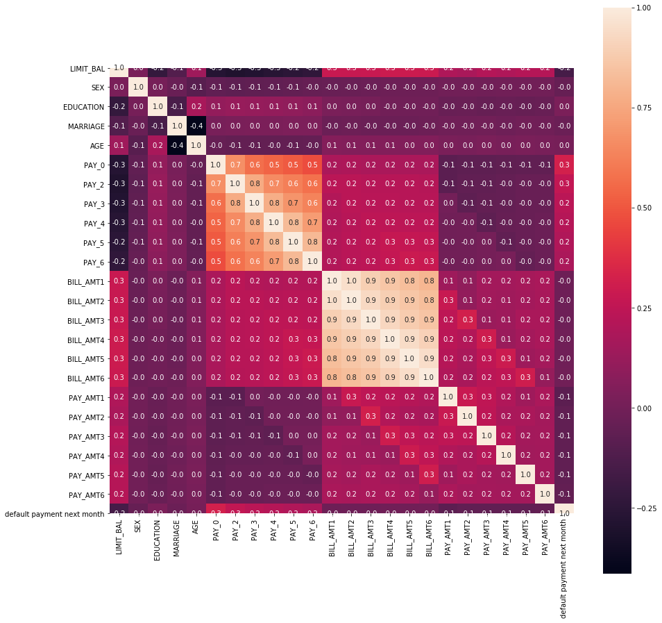

```python
plt.subplots(1,1,figsize=(15,15))
sns.heatmap(corr,square=True,annot=True,fmt='.1f')
plt.show()
```

### Exploratory Data Analysis

##### Data Cleaning

**Since there is no clear definition of what 0,4,5,6 in the `EDUCATION` column refers to, we can group all the three into label 4='others'**

```python
df['EDUCATION'].replace({5:4,6:4,0:4},inplace=True)
```

```
0    23364
1     6636
Name: default payment next month, dtype: int64
```

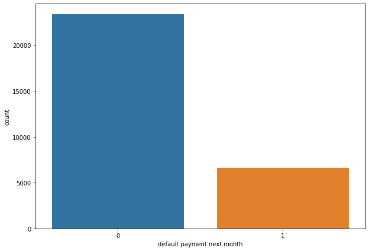

```python
plt.subplots(1,1,figsize=(10,7))
sns.countplot(df['default payment next month'])
print(df['default payment next month'].value_counts())
plt.show()
```

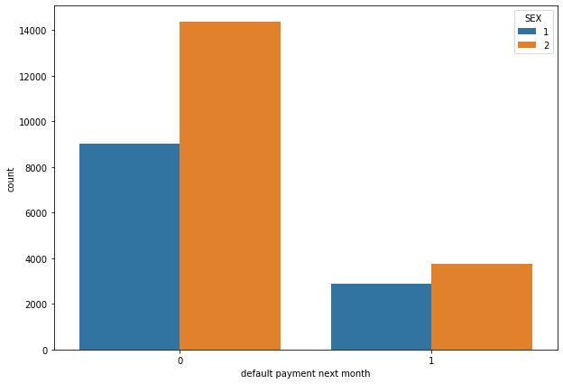

```python
plt.subplots(1,1,figsize=(10,7))
sns.countplot(df['default payment next month'],hue=df['SEX'])
plt.show()
```

1. Apparently Sex 2 has higher number of records with no defaults.
2. Wrt defaulted records, Sex 2 has higher records than Sex 1 but by a small margin.

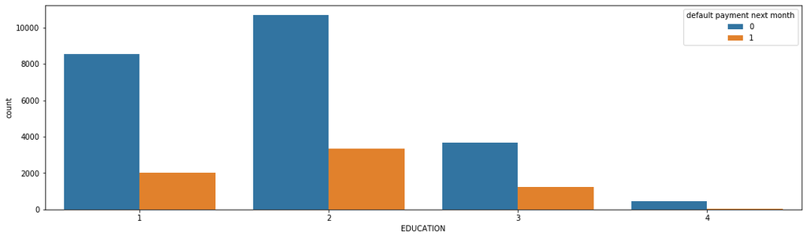

```python
fig,axes=plt.subplots(1,1,figsize=(18,5))
sns.countplot(df['EDUCATION'],hue=df['default payment next month'])
#sns.countplot(df[df['default payment next month']==1]['EDUCATION'],ax=axes[1])
plt.show()
```

```python
df.groupby('EDUCATION').sum()['default payment next month']/df.groupby('EDUCATION').count()['AGE']
```

```
EDUCATION
1    0.192348
2    0.237349
3    0.251576
4    0.070513
dtype: float64
```

1. Ratio of defaulters to the total seems to be higher in the education 3 category.
2. Education 2 category has highest number of records of all.
3. Education 4 category have no significant number of records comparatively.

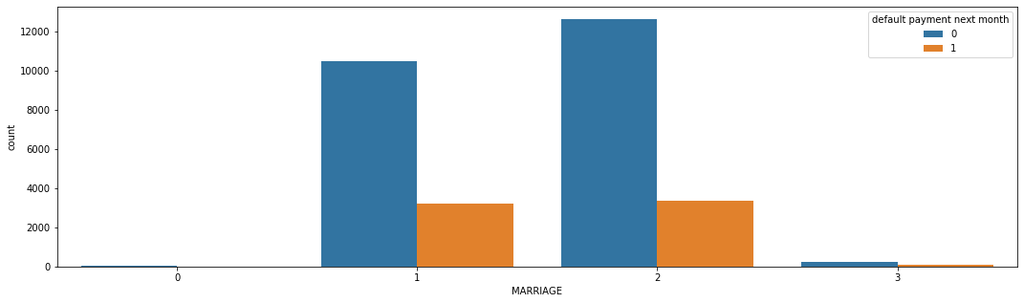

```python
fig,axes=plt.subplots(1,1,figsize=(18,5))
sns.countplot(df['MARRIAGE'],hue=df['default payment next month'])
plt.show()
```

```python
df.groupby('MARRIAGE').sum()['default payment next month']/df.groupby('MARRIAGE').count()['AGE']
```

```
MARRIAGE
0    0.092593
1    0.234717
2    0.209283
3    0.260062
dtype: float64
```

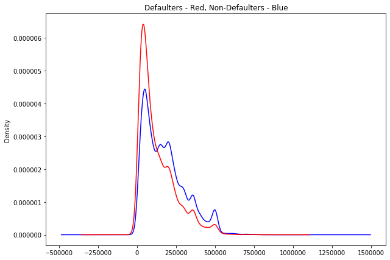

```python
plt.subplots(1,1,figsize=(10,7))
df[df['default payment next month']==0]['LIMIT_BAL'].plot(kind='kde',c='b')
df[df['default payment next month']==1]['LIMIT_BAL'].plot(kind='kde',c='r')
plt.title('Defaulters - Red, Non-Defaulters - Blue')
plt.show()
```

1. There seems to be no clear boundary between defaulters and non defaulters in the `LIMIT_BAL` column.

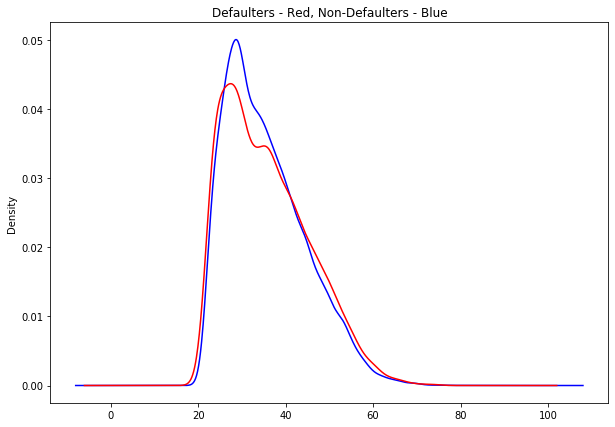

```python
plt.subplots(1,1,figsize=(10,7))
df[df['default payment next month']==0]['AGE'].plot(kind='kde',c='b')
df[df['default payment next month']==1]['AGE'].plot(kind='kde',c='r')
plt.title('Defaulters - Red, Non-Defaulters - Blue')
plt.show()
```

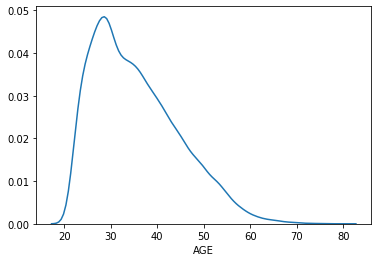

```python
sns.distplot(df['AGE'],hist=False)
plt.show()
```

1. There seems to be no clear boundary between defaulters and non defaulters in the `AGE` column.
2. Distribution of `AGE` column seems to be right skewed.
3. Most of the columns come in the age range of 20-40

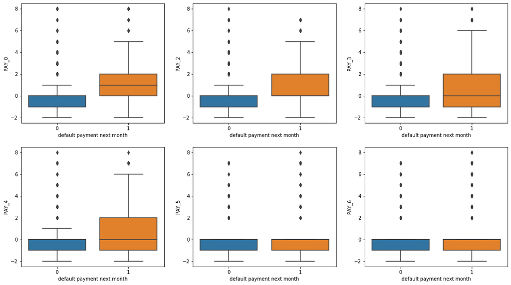

```python
col_list=['PAY_0','PAY_2','PAY_3','PAY_4','PAY_5','PAY_6']
ctr=0
fig,axes=plt.subplots(2,3,figsize=(18,10))
for i in range(2):
    for j in range(3):
        sns.boxplot(df['default payment next month'],df[col_list[ctr]],ax=axes[i][j])
        ctr+=1
plt.show()
```

1. We can see that the two columns `PAY_5` and `PAY_6` don't have any differnce in the distribution of values with defaulters and non defaulters.
2. `PAY_0` column seems to exhibit the highest of difference in the distribution of values from defaulters and non defaulters.

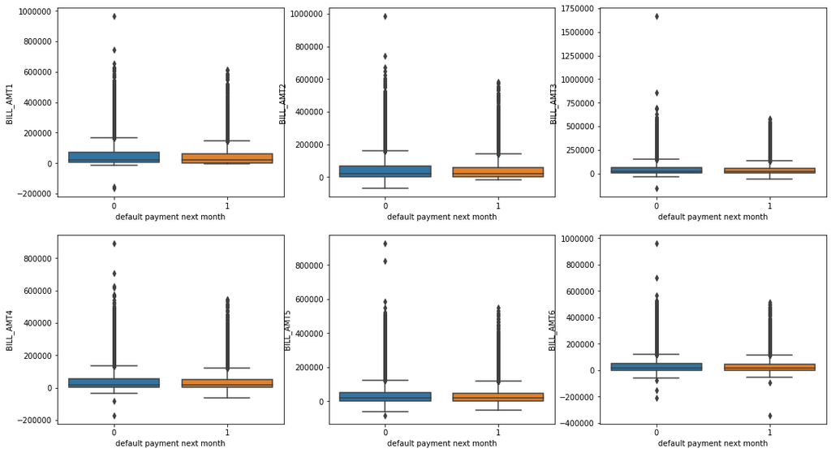

```python
col_list=['BILL_AMT1','BILL_AMT2','BILL_AMT3','BILL_AMT4','BILL_AMT5','BILL_AMT6']
ctr=0
fig,axes=plt.subplots(2,3,figsize=(18,10))
for i in range(2):
    for j in range(3):
        sns.boxplot(df['default payment next month'],df[col_list[ctr]],ax=axes[i][j])
        ctr+=1
plt.show()
```

1. None of the columns in the above plots seems to have a significant difference in the distribution of values from defaulters and non defaulters.
2. These may not be the best set of variables to determine the class.

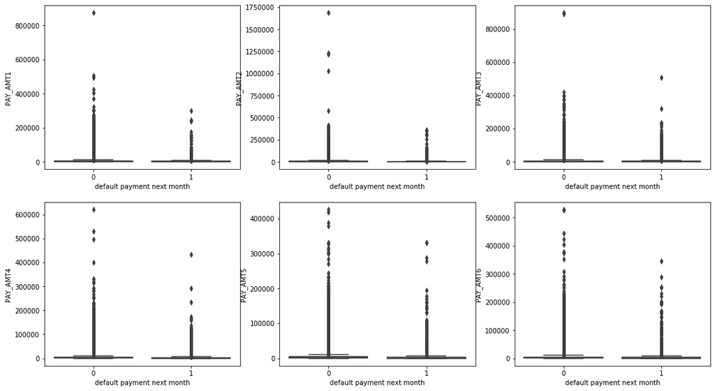

```python
col_list=['PAY_AMT1','PAY_AMT2','PAY_AMT3','PAY_AMT4','PAY_AMT5','PAY_AMT6']
ctr=0
fig,axes=plt.subplots(2,3,figsize=(18,10))
for i in range(2):
    for j in range(3):
        sns.boxplot(df['default payment next month'],df[col_list[ctr]],ax=axes[i][j])
        ctr+=1
plt.show()
```

1. None of the columns in the above plots seems to have a significant difference in the distribution of values from defaulters and non defaulters.
2. These may not be the best set of variables to determine the class.
3. Outliers seem to be larger in the case of non defaulters in all of the above columns.

##### Encoding Categorical Columns

```python
cat_cols=['SEX','EDUCATION','MARRIAGE']
cont_cols=['BILL_AMT1','BILL_AMT2','BILL_AMT3','BILL_AMT4','BILL_AMT5','BILL_AMT6',
          'PAY_AMT1','PAY_AMT2','PAY_AMT3','PAY_AMT4','PAY_AMT5','PAY_AMT6','AGE','PAY_0','PAY_2','PAY_3','PAY_4','PAY_5','PAY_6']
```

```python
dummies=pd.get_dummies(df[cat_cols],prefix_sep='_is_',columns=cat_cols,drop_first=True)
```

### Model Building

```python
#importing some performance metrics and random split functions
from sklearn.model_selection import train_test_split,cross_val_score
from sklearn.preprocessing import StandardScaler
```

##### Logistic Regression

```python
from sklearn.linear_model import LogisticRegression
```

```python
cont_col_scaled=StandardScaler().fit_transform(df[cont_cols])
x=pd.concat((dummies,pd.DataFrame(cont_col_scaled,columns=cont_cols)),axis=1)
y=df['default payment next month']
xtrain,xtest,ytrain,ytest=train_test_split(x,y,train_size=0.8,random_state=0)
```

```python
log_reg=LogisticRegression()
log_reg.fit(xtrain,ytrain)
```

```
LogisticRegression(C=1.0, class_weight=None, dual=False, fit_intercept=True,
                   intercept_scaling=1, l1_ratio=None, max_iter=100,
                   multi_class='auto', n_jobs=None, penalty='l2',
                   random_state=None, solver='lbfgs', tol=0.0001, verbose=0,
                   warm_start=False)
```

```python
print('Basic Logistic Regression score for train data:',log_reg.score(xtrain,ytrain))
print('Basic Logistic Regression score for test data:',log_reg.score(xtest,ytest))
```

```
Basic Logistic Regression score for train data: 0.80875
Basic Logistic Regression score for test data: 0.8191666666666667
```

```python
print('Cross Validation Score for the Logistic Regression model:')
cv_scorelog=cross_val_score(log_reg,x,y,cv=7)
print('Bias Error:',1-np.mean(cv_scorelog))
print('Variance Error:',np.std(cv_scorelog))
```

```
Cross Validation Score for the Logistic Regression model:
Bias Error: 0.19009998322165533
Variance Error: 0.006611397937128726
```

##### K Nearest Neighbours

```python
from sklearn.neighbors import KNeighborsClassifier
```

```python
knn_model=KNeighborsClassifier()
knn_model.fit(xtrain,ytrain)
```

```
KNeighborsClassifier(algorithm='auto', leaf_size=30, metric='minkowski',
                     metric_params=None, n_jobs=None, n_neighbors=5, p=2,
                     weights='uniform')
```

```python
print('Basic KNNeighbours Model score for train data:',knn_model.score(xtrain,ytrain))
print('Basic KNNeighbours Model score for test data:',knn_model.score(xtest,ytest))
```

```
Basic KNNeighbours Model score for train data: 0.8437916666666667
Basic KNNeighbours Model score for test data: 0.797
```

```python
print('Cross Validation Score for the KNeighbours model:')
cv_scoreknn=cross_val_score(knn_model,x,y,cv=7)
print('Bias Error:',1-np.mean(cv_scoreknn))
print('Variance Error:',np.std(cv_scoreknn))
```

```
Cross Validation Score for the KNeighbours model:
Bias Error: 0.20653275779280988
Variance Error: 0.007523094410845382
```

##### Decision Tree

```python
from sklearn.tree import DecisionTreeClassifier
```

```python
dt=DecisionTreeClassifier()
dt.fit(xtrain,ytrain)
```

```
DecisionTreeClassifier(ccp_alpha=0.0, class_weight=None, criterion='gini',
                       max_depth=None, max_features=None, max_leaf_nodes=None,
                       min_impurity_decrease=0.0, min_impurity_split=None,
                       min_samples_leaf=1, min_samples_split=2,
                       min_weight_fraction_leaf=0.0, presort='deprecated',
                       random_state=None, splitter='best')
```

```python
print('Basic Decision Tree score for train data:',dt.score(xtrain,ytrain))
print('Basic Decision Tree score for test data:',dt.score(xtest,ytest))
```

```
Basic Decision Tree score for train data: 0.995625
Basic Decision Tree score for test data: 0.7248333333333333
```

```python
print('Cross Validation Score for the Decision Tree model:')
cv_scoredt=cross_val_score(dt,x,y,cv=7)
print('Bias Error:',1-np.mean(cv_scoredt))
print('Variance Error:',np.std(cv_scoredt))
```

```
Cross Validation Score for the Decision Tree model:
Bias Error: 0.2710993985076219
Variance Error: 0.012199575245236417
```

##### Random Forest

```python
from sklearn.ensemble import RandomForestClassifier
```

```python
rf=RandomForestClassifier()
rf.fit(xtrain,ytrain)
```

```
RandomForestClassifier(bootstrap=True, ccp_alpha=0.0, class_weight=None,
                       criterion='gini', max_depth=None, max_features='auto',
                       max_leaf_nodes=None, max_samples=None,
                       min_impurity_decrease=0.0, min_impurity_split=None,
                       min_samples_leaf=1, min_samples_split=2,
                       min_weight_fraction_leaf=0.0, n_estimators=100,
                       n_jobs=None, oob_score=False, random_state=None,
                       verbose=0, warm_start=False)
```

```python
print('Basic Random Forest score for train data:',rf.score(xtrain,ytrain))
print('Basic Random Forest score for test data:',rf.score(xtest,ytest))
```

```
Basic Random Forest score for train data: 0.9955833333333334
Basic Random Forest score for test data: 0.8241666666666667
```

```python
print('Cross Validation Score for the Random Forest model:')
cv_scorerf=cross_val_score(rf,x,y,cv=7)
print('Bias Error:',1-np.mean(cv_scorerf))
print('Variance Error:',np.std(cv_scorerf))
```

```
Cross Validation Score for the Random Forest model:
Bias Error: 0.18499944422219372
Variance Error: 0.010593294008153236
```

##### Ada Boost

```python
from sklearn.ensemble import AdaBoostClassifier
```

```python
ab=AdaBoostClassifier()
ab.fit(xtrain,ytrain)
```

```
AdaBoostClassifier(algorithm='SAMME.R', base_estimator=None, learning_rate=1.0,
                   n_estimators=50, random_state=None)
```

```python
print('Basic Ada Boost score for train data:',ab.score(xtrain,ytrain))
print('Basic Ada Boost score for test data:',ab.score(xtest,ytest))
```

```
Basic Ada Boost score for train data: 0.8151666666666667
Basic Ada Boost score for test data: 0.824
```

```python
print('Cross Validation Score for the Ada Boost model:')
cv_scoreab=cross_val_score(ab,x,y,cv=7)
print('Bias Error:',1-np.mean(cv_scoreab))
print('Variance Error:',np.std(cv_scoreab))
```

```
Cross Validation Score for the Ada Boost model:
Bias Error: 0.18289954532008257
Variance Error: 0.009186683765660257
```

##### Gradient Boost

```python
from sklearn.ensemble import GradientBoostingClassifier
```

```python
gb=GradientBoostingClassifier()
gb.fit(xtrain,ytrain)
```

```
GradientBoostingClassifier(ccp_alpha=0.0, criterion='friedman_mse', init=None,
                           learning_rate=0.1, loss='deviance', max_depth=3,
                           max_features=None, max_leaf_nodes=None,
                           min_impurity_decrease=0.0, min_impurity_split=None,
                           min_samples_leaf=1, min_samples_split=2,
                           min_weight_fraction_leaf=0.0, n_estimators=100,
                           n_iter_no_change=None, presort='deprecated',
                           random_state=None, subsample=1.0, tol=0.0001,
                           validation_fraction=0.1, verbose=0,
                           warm_start=False)
```

```python
print('Basic Gradient Boost score for train data:',gb.score(xtrain,ytrain))
print('Basic Gradient Boost score for test data:',gb.score(xtest,ytest))
```

```
Basic Gradient Boost score for train data: 0.824875
Basic Gradient Boost score for test data: 0.8295
```

```python
print('Cross Validation Score for the Gradient Boost model:')
cv_scoregb=cross_val_score(gb,x,y,cv=7)
print('Bias Error:',1-np.mean(cv_scoregb))
print('Variance Error:',np.std(cv_scoregb))
```

```
Cross Validation Score for the Gradient Boost model:
Bias Error: 0.1789661552707067
Variance Error: 0.010297613624951976
```

##### XG Boost

```python
from xgboost import XGBClassifier
```

```python
xgb=XGBClassifier()
xgb.fit(xtrain,ytrain)
```

```
XGBClassifier(base_score=0.5, booster='gbtree', colsample_bylevel=1,
              colsample_bynode=1, colsample_bytree=1, gamma=0, gpu_id=-1,
              importance_type='gain', interaction_constraints='',
              learning_rate=0.300000012, max_delta_step=0, max_depth=6,
              min_child_weight=1, missing=nan, monotone_constraints='()',
              n_estimators=100, n_jobs=0, num_parallel_tree=1,
              objective='binary:logistic', random_state=0, reg_alpha=0,
              reg_lambda=1, scale_pos_weight=1, subsample=1,
              tree_method='exact', validate_parameters=1, verbosity=None)
```

```python
print('Basic XG Boost score for train data:',xgb.score(xtrain,ytrain))
print('Basic XG Boost score for test data:',xgb.score(xtest,ytest))
```

```
Basic XG Boost score for train data: 0.8795
Basic XG Boost score for test data: 0.8206666666666667
```

```python
print('Cross Validation Score for the XG Boost model:')
cv_scorexgb=cross_val_score(xgb,x,y,cv=7)
print('Bias Error:',1-np.mean(cv_scorexgb))
print('Variance Error:',np.std(cv_scorexgb))
```

```
Cross Validation Score for the XG Boost model:
Bias Error: 0.18446613088493435
Variance Error: 0.010351894608699083
```

### Basic Models Evaluation

```python
from sklearn.metrics import roc_auc_score
```

```python
basic_models={'Logistic Regression':log_reg,'K Nearest Neighbours':knn_model,
              'Decision Tree':dt,'Random forest':rf,'Ada Boost':ab,'Gradient Boost':gb,'XG Boost':xgb}
values_list={'Train Data Score':[],'Test Data Score':[],'Bias Error':[],'Variance Error':[],'Test ROC AUC':[]}
cv_list=[cv_scorelog,cv_scoreknn,cv_scoredt,cv_scorerf,cv_scoreab,cv_scoregb,cv_scorexgb]
for i,j in enumerate(basic_models.values()):
    values_list['Train Data Score'].append(j.score(xtrain,ytrain))
    values_list['Test Data Score'].append(j.score(xtest,ytest))
    values_list['Bias Error'].append(1-np.mean(cv_list[i]))
    values_list['Variance Error'].append(np.std(cv_list[i]))
    values_list['Test ROC AUC'].append(roc_auc_score(ytest,j.predict_proba(xtest)[:,1]))
basic_models_performance=pd.DataFrame(values_list,index=basic_models.keys())
basic_models_performance
```

|  | Train Data Score | Test Data Score | Bias Error | Variance Error | Test ROC AUC |
| --- | --- | --- | --- | --- | --- |
| Logistic Regression | 0.808750 | 0.819167 | 0.190100 | 0.006611 | 0.718757 |
| K Nearest Neighbours | 0.843792 | 0.797000 | 0.206533 | 0.007523 | 0.704093 |
| Decision Tree | 0.995625 | 0.724833 | 0.271099 | 0.012200 | 0.612138 |
| Random forest | 0.995583 | 0.824167 | 0.184999 | 0.010593 | 0.757728 |
| Ada Boost | 0.815167 | 0.824000 | 0.182900 | 0.009187 | 0.771775 |
| Gradient Boost | 0.824875 | 0.829500 | 0.178966 | 0.010298 | 0.775461 |
| XG Boost | 0.879500 | 0.820667 | 0.184466 | 0.010352 | 0.754186 |

### Model Tuning

```python
#importing random search
from sklearn.model_selection import RandomizedSearchCV
```

##### Logistic Regression

```python
est=LogisticRegression()
params={'penalty':['l1','l2'],'C':[0.01,0.1,1,10],'class_weight':[None,'balanced'],'random_state':[0]}
rs_logreg=RandomizedSearchCV(est,params,random_state=0,scoring='accuracy',n_jobs=-1)
rs_logreg.fit(xtrain,ytrain)
rs_logreg.best_params_
```

```
{'random_state': 0, 'penalty': 'l2', 'class_weight': None, 'C': 1}
```

```python
logregt=LogisticRegression(random_state=0,penalty='l2',class_weight=None,C=1)
logregt.fit(xtrain,ytrain)
```

```
LogisticRegression(C=1, class_weight=None, dual=False, fit_intercept=True,
                   intercept_scaling=1, l1_ratio=None, max_iter=100,
                   multi_class='auto', n_jobs=None, penalty='l2',
                   random_state=0, solver='lbfgs', tol=0.0001, verbose=0,
                   warm_start=False)
```

```python
print('Tuned Logistic Regression for train data:',logregt.score(xtrain,ytrain))
print('Tuned Logistic Regression score for test data:',logregt.score(xtest,ytest))
```

```
Tuned Logistic Regression for train data: 0.80875
Tuned Logistic Regression score for test data: 0.8191666666666667
```

```python
print('Cross Validation Score for the Tuned Logistic Regression Model:')
cv_scorelogregt=cross_val_score(logregt,x,y,cv=7)
print('Bias Error:',1-np.mean(cv_scorelogregt))
print('Variance Error:',np.std(cv_scorelogregt))
```

```
Cross Validation Score for the Tuned Logistic Regression Model:
Bias Error: 0.19009998322165533
Variance Error: 0.006611397937128726
```

##### K Nearest Neighbours.

```python
scores={}
for i in range(1,21):
    knn=KNeighborsClassifier(i)
    knn.fit(xtrain,ytrain)
    scores[i]=(knn.score(xtrain,ytrain),knn.score(xtest,ytest))
pd.Series(scores)
```

```
1               (0.994875, 0.7218333333333333)
2                               (0.864, 0.792)
3     (0.8662083333333334, 0.7803333333333333)
4     (0.8431666666666666, 0.8041666666666667)
5                  (0.8437916666666667, 0.797)
6     (0.8344583333333333, 0.8063333333333333)
7                            (0.835625, 0.805)
8     (0.8300416666666667, 0.8121666666666667)
9     (0.8302916666666667, 0.8113333333333334)
10               (0.82825, 0.8136666666666666)
11                 (0.8275416666666666, 0.813)
12    (0.8249583333333333, 0.8161666666666667)
13    (0.8253333333333334, 0.8158333333333333)
14              (0.822875, 0.8178333333333333)
15                           (0.82375, 0.8155)
16                 (0.8227083333333334, 0.817)
17    (0.8228333333333333, 0.8156666666666667)
18                 (0.8219166666666666, 0.816)
19                (0.8215, 0.8168333333333333)
20    (0.8214166666666667, 0.8176666666666667)
dtype: object
```

**k=19 gives the best fit with more optimal train and test data score.**

```python
#best k value model
knnt=KNeighborsClassifier(19)
knnt.fit(xtrain,ytrain)
```

```
KNeighborsClassifier(algorithm='auto', leaf_size=30, metric='minkowski',
                     metric_params=None, n_jobs=None, n_neighbors=19, p=2,
                     weights='uniform')
```

```python
print('Tuned K Nearest Neighbours score for train data:',knnt.score(xtrain,ytrain))
print('Tuned K Nearest Neighbours for test data:',knnt.score(xtest,ytest))
```

```
Tuned K Nearest Neighbours score for train data: 0.8215
Tuned K Nearest Neighbours for test data: 0.8168333333333333
```

```python
print('Cross Validation Score for the Tuned K Nearest Neighbours Model:')
cv_scoreknnt=cross_val_score(knnt,x,y,cv=7)
print('Bias Error:',1-np.mean(cv_scoreknnt))
print('Variance Error:',np.std(cv_scoreknnt))
```

```
Cross Validation Score for the Tuned K Nearest Neighbours Model:
Bias Error: 0.18873285538257
Variance Error: 0.008325429591810388
```

##### Decision Tree

```python
est=DecisionTreeClassifier()
params={'criterion':['gini','entropy'],'splitter':['best','random'],'max_depth':range(1,16),
       'min_samples_split':range(1,11),'min_samples_leaf':range(1,11),'random_state':[0],'class_weight':['balanced',None],
       'max_features':['sqrt','log2',None]}
rs_dtt=RandomizedSearchCV(est,params,random_state=0,scoring='accuracy',n_jobs=-1)
rs_dtt.fit(xtrain,ytrain)
rs_dtt.best_params_
```

```
{'splitter': 'best',
 'random_state': 0,
 'min_samples_split': 6,
 'min_samples_leaf': 2,
 'max_features': None,
 'max_depth': 9,
 'criterion': 'entropy',
 'class_weight': None}
```

```python
dtt=DecisionTreeClassifier(splitter='random',random_state=0,min_samples_split=2,min_samples_leaf=1,max_features=None,max_depth=6,
                          criterion='entropy',class_weight=None)
dtt.fit(xtrain,ytrain)
```

```
DecisionTreeClassifier(ccp_alpha=0.0, class_weight=None, criterion='entropy',
                       max_depth=6, max_features=None, max_leaf_nodes=None,
                       min_impurity_decrease=0.0, min_impurity_split=None,
                       min_samples_leaf=1, min_samples_split=2,
                       min_weight_fraction_leaf=0.0, presort='deprecated',
                       random_state=0, splitter='random')
```

```python
print('Tuned Decision Tree score for train data:',dtt.score(xtrain,ytrain))
print('Tuned Decision Tree for test data:',dtt.score(xtest,ytest))
```

```
Tuned Decision Tree score for train data: 0.8090833333333334
Tuned Decision Tree for test data: 0.8125
```

```python
print('Cross Validation Score for the Tuned Decision Tree Model:')
cv_scoredtt=cross_val_score(dtt,x,y,cv=7)
print('Bias Error:',1-np.mean(cv_scoredtt))
print('Variance Error:',np.std(cv_scoredtt))
```

```
Cross Validation Score for the Tuned Decision Tree Model:
Bias Error: 0.18819955760242202
Variance Error: 0.008154791969074171
```

##### Random Forest

```python
est=RandomForestClassifier()
params={'criterion':['gini','entropy'],'max_depth':range(1,16),
       'min_samples_split':range(1,11),'min_samples_leaf':range(1,11),'random_state':[0],'class_weight':['balanced',None],
       'max_features':['sqrt','log2',None],'max_samples':np.arange(0.3,1.1,0.1),'n_estimators':range(100,350,50)}
rs_rft=RandomizedSearchCV(est,params,random_state=0,scoring='accuracy',n_jobs=-1)
rs_rft.fit(xtrain,ytrain)
rs_rft.best_params_
```

```
{'random_state': 0,
 'n_estimators': 150,
 'min_samples_split': 7,
 'min_samples_leaf': 2,
 'max_samples': 0.8000000000000003,
 'max_features': None,
 'max_depth': 6,
 'criterion': 'entropy',
 'class_weight': None}
```

```python
rft=RandomForestClassifier(random_state=0,n_estimators=150,min_samples_split=7,min_samples_leaf=2,max_samples=0.8,max_features=None,
                          criterion='entropy',class_weight=None)
rft.fit(xtrain,ytrain)
```

```
RandomForestClassifier(bootstrap=True, ccp_alpha=0.0, class_weight=None,
                       criterion='entropy', max_depth=None, max_features=None,
                       max_leaf_nodes=None, max_samples=0.8,
                       min_impurity_decrease=0.0, min_impurity_split=None,
                       min_samples_leaf=2, min_samples_split=7,
                       min_weight_fraction_leaf=0.0, n_estimators=150,
                       n_jobs=None, oob_score=False, random_state=0, verbose=0,
                       warm_start=False)
```

```python
print('Tuned Random Forest score for train data:',rft.score(xtrain,ytrain))
print('Tuned Random Forest for test data:',rft.score(xtest,ytest))
```

```
Tuned Random Forest score for train data: 0.950375
Tuned Random Forest for test data: 0.8228333333333333
```

```python
print('Cross Validation Score for the Random Forest Model:')
cv_scorerft=cross_val_score(rft,x,y,cv=7)
print('Bias Error:',1-np.mean(cv_scorerft))
print('Variance Error:',np.std(cv_scorerft))
```

```
Cross Validation Score for the Random Forest Model:
Bias Error: 0.18196623531204492
Variance Error: 0.009605984954831656
```

##### Ada Boost

```python
est=AdaBoostClassifier()
params={'random_state':[0],'n_estimators':np.arange(50,250,50),'algorithm':['SAMME','SAMME.R']}
rs_abt=RandomizedSearchCV(est,params,random_state=0,scoring='accuracy',n_jobs=-1)
rs_abt.fit(xtrain,ytrain)
rs_abt.best_params_
```

```
{'random_state': 0, 'n_estimators': 150, 'algorithm': 'SAMME'}
```

```python
abt=AdaBoostClassifier(random_state=0,n_estimators=150,algorithm='SAMME')
abt.fit(xtrain,ytrain)
```

```
AdaBoostClassifier(algorithm='SAMME', base_estimator=None, learning_rate=1.0,
                   n_estimators=150, random_state=0)
```

```python
print('Tuned Ada Boost score for train data:',abt.score(xtrain,ytrain))
print('Tuned Ada Boost for test data:',abt.score(xtest,ytest))
```

```
Tuned Ada Boost score for train data: 0.816625
Tuned Ada Boost for test data: 0.8253333333333334
```

```python
print('Cross Validation Score for the Ada Boost Model:')
cv_scoreabt=cross_val_score(abt,x,y,cv=7)
print('Bias Error:',1-np.mean(cv_scoreabt))
print('Variance Error:',np.std(cv_scoreabt))
```

```
Cross Validation Score for the Ada Boost Model:
Bias Error: 0.18139958308497062
Variance Error: 0.009898415421355524
```

##### Gradient Boost

```python
est=GradientBoostingClassifier()
params={'random_state':[0],'min_samples_split':range(1,11),'min_samples_leaf':range(1,11),
        'n_estimators':np.arange(50,350,50),'max_depth':range(1,16),'max_features':['sqrt','log2',None],
       'loss':['deviance','exponential']}
rs_gbt=RandomizedSearchCV(est,params,random_state=0,scoring='accuracy',n_jobs=-1)
rs_gbt.fit(xtrain,ytrain)
rs_gbt.best_params_
```

```
{'random_state': 0,
 'n_estimators': 100,
 'min_samples_split': 8,
 'min_samples_leaf': 7,
 'max_features': None,
 'max_depth': 2,
 'loss': 'exponential'}
```

```python
gbt=GradientBoostingClassifier(random_state=0,n_estimators=100,min_samples_split=8,
                               min_samples_leaf=7,max_features=None,max_depth=2,loss='exponential')

gbt.fit(xtrain,ytrain)
```

```
GradientBoostingClassifier(ccp_alpha=0.0, criterion='friedman_mse', init=None,
                           learning_rate=0.1, loss='exponential', max_depth=2,
                           max_features=None, max_leaf_nodes=None,
                           min_impurity_decrease=0.0, min_impurity_split=None,
                           min_samples_leaf=7, min_samples_split=8,
                           min_weight_fraction_leaf=0.0, n_estimators=100,
                           n_iter_no_change=None, presort='deprecated',
                           random_state=0, subsample=1.0, tol=0.0001,
                           validation_fraction=0.1, verbose=0,
                           warm_start=False)
```

```python
print('Tuned Gradient Boost score for train data:',gbt.score(xtrain,ytrain))
print('Tuned Gradient Boost for test data:',gbt.score(xtest,ytest))
```

```
Tuned Gradient Boost score for train data: 0.8200416666666667
Tuned Gradient Boost for test data: 0.83
```

```python
print('Cross Validation Score for the Gradient Boost Model:')
cv_scoregbt=cross_val_score(gbt,x,y,cv=7)
print('Bias Error:',1-np.mean(cv_scoregbt))
print('Variance Error:',np.std(cv_scoregbt))
```

```
Cross Validation Score for the Gradient Boost Model:
Bias Error: 0.17883275304011248
Variance Error: 0.01081865109346356
```

##### XG Boost

```python
est=XGBClassifier()
params={'random_state':[0],
        'n_estimators':np.arange(50,350,50),'max_depth':range(1,16),'booster':['gbtree','gblinear','dart'],
        'subsample':np.arange(0.3,0.9,0.1),'reg_alpha':np.arange(0.1,0.8,0.1),'reg_lambda':np.arange(0.1,0.8,0.1)
       }
rs_xgbt=RandomizedSearchCV(est,params,random_state=0,scoring='accuracy',n_jobs=-1)
rs_xgbt.fit(xtrain,ytrain)
rs_xgbt.best_params_
```

```
{'subsample': 0.7000000000000002,
 'reg_lambda': 0.2,
 'reg_alpha': 0.1,
 'random_state': 0,
 'n_estimators': 100,
 'max_depth': 4,
 'booster': 'dart'}
```

```python
xgbt=XGBClassifier(subsample=0.7,reg_lambda=0.2,reg_alpha=0.1,random_state=0,n_estimators=100,max_depth=4,booster='dart')
xgbt.fit(xtrain,ytrain)
```

```
XGBClassifier(base_score=0.5, booster='dart', colsample_bylevel=1,
              colsample_bynode=1, colsample_bytree=1, gamma=0, gpu_id=-1,
              importance_type='gain', interaction_constraints='',
              learning_rate=0.300000012, max_delta_step=0, max_depth=4,
              min_child_weight=1, missing=nan, monotone_constraints='()',
              n_estimators=100, n_jobs=0, num_parallel_tree=1,
              objective='binary:logistic', random_state=0, reg_alpha=0.1,
              reg_lambda=0.2, scale_pos_weight=1, subsample=0.7,
              tree_method='exact', validate_parameters=1, verbosity=None)
```

```python
print('Tuned XG Boost score for train data:',xgbt.score(xtrain,ytrain))
print('Tuned XG Boost for test data:',xgbt.score(xtest,ytest))
```

```
Tuned XG Boost score for train data: 0.8420833333333333
Tuned XG Boost for test data: 0.8245
```

```python
print('Cross Validation Score for the XG Boost Model:')
cv_scorexgbt=cross_val_score(xgbt,x,y,cv=7)
print('Bias Error:',1-np.mean(cv_scorexgbt))
print('Variance Error:',np.std(cv_scorexgbt))
```

```
Cross Validation Score for the XG Boost Model:
Bias Error: 0.18289967755552983
Variance Error: 0.010189215688038817
```

### Tuned Models Evaluation

```python
tuned_models={'Tuned Logistic Regression':logregt,'Tuned K Nearest Neighbours':knnt,
              'Tuned Decision Tree':dtt,'Tuned Random forest':rft,
              'Tuned Ada Boost':abt,'Tuned Gradient Boost':gbt,'Tuned XG Boost':xgbt}
values_list={'Train Data Score':[],'Test Data Score':[],'Bias Error':[],'Variance Error':[],'Test ROC AUC':[]}
cv_list=[cv_scorelogregt,cv_scoreknnt,cv_scoredtt,cv_scorerft,cv_scoreabt,cv_scoregbt,cv_scorexgbt]
for i,j in enumerate(tuned_models.values()):
    values_list['Train Data Score'].append(j.score(xtrain,ytrain))
    values_list['Test Data Score'].append(j.score(xtest,ytest))
    values_list['Bias Error'].append(1-np.mean(cv_list[i]))
    values_list['Variance Error'].append(np.std(cv_list[i]))
    values_list['Test ROC AUC'].append(roc_auc_score(ytest,j.predict_proba(xtest)[:,1]))
tuned_models_performance=pd.DataFrame(values_list,index=tuned_models.keys())
tuned_models_performance
```

|  | Train Data Score | Test Data Score | Bias Error | Variance Error | Test ROC AUC |
| --- | --- | --- | --- | --- | --- |
| Tuned Logistic Regression | 0.808750 | 0.819167 | 0.190100 | 0.006611 | 0.718757 |
| Tuned K Nearest Neighbours | 0.821500 | 0.816833 | 0.188733 | 0.008325 | 0.738121 |
| Tuned Decision Tree | 0.809083 | 0.812500 | 0.188200 | 0.008155 | 0.694297 |
| Tuned Random forest | 0.950375 | 0.822833 | 0.181966 | 0.009606 | 0.765258 |
| Tuned Ada Boost | 0.816625 | 0.825333 | 0.181400 | 0.009898 | 0.767860 |
| Tuned Gradient Boost | 0.820042 | 0.830000 | 0.178833 | 0.010819 | 0.774602 |
| Tuned XG Boost | 0.842083 | 0.824500 | 0.182900 | 0.010189 | 0.765342 |

### All Models Evaluation Performance Visualisation

```python
from sklearn.metrics import confusion_matrix
```

```python
sensitivity=[]
specificity=[]
for i in basic_models.values():
    conf_mat=confusion_matrix(ytest,i.predict(xtest),[1,0])
    sensitivity.append(conf_mat[0][0]/(conf_mat[0][0]+conf_mat[0][1]))
    specificity.append(conf_mat[1][1]/(conf_mat[1][1]+conf_mat[1][0]))
for i in tuned_models.values():
    conf_mat=confusion_matrix(ytest,i.predict(xtest),[1,0])
    sensitivity.append(conf_mat[0][0]/(conf_mat[0][0]+conf_mat[0][1]))
    specificity.append(conf_mat[1][1]/(conf_mat[1][1]+conf_mat[1][0]))
```

```python
all_models=pd.concat((basic_models_performance,tuned_models_performance))
all_models['Sensitivity']=sensitivity
all_models['Specificity']=specificity
all_models
```

|  | Train Data Score | Test Data Score | Bias Error | Variance Error | Test ROC AUC | Sensitivity | Specificity |
| --- | --- | --- | --- | --- | --- | --- | --- |
| Logistic Regression | 0.808750 | 0.819167 | 0.190100 | 0.006611 | 0.718757 | 0.239013 | 0.979162 |
| K Nearest Neighbours | 0.843792 | 0.797000 | 0.206533 | 0.007523 | 0.704093 | 0.373940 | 0.913672 |
| Decision Tree | 0.995625 | 0.724833 | 0.271099 | 0.012200 | 0.612138 | 0.404009 | 0.813311 |
| Random forest | 0.995583 | 0.824167 | 0.184999 | 0.010593 | 0.757728 | 0.378566 | 0.947055 |
| Ada Boost | 0.815167 | 0.824000 | 0.182900 | 0.009187 | 0.771775 | 0.323053 | 0.962152 |
| Gradient Boost | 0.824875 | 0.829500 | 0.178966 | 0.010298 | 0.775461 | 0.377024 | 0.954284 |
| XG Boost | 0.879500 | 0.820667 | 0.184466 | 0.010352 | 0.754186 | 0.361604 | 0.947268 |
| Tuned Logistic Regression | 0.808750 | 0.819167 | 0.190100 | 0.006611 | 0.718757 | 0.239013 | 0.979162 |
| Tuned K Nearest Neighbours | 0.821500 | 0.816833 | 0.188733 | 0.008325 | 0.738121 | 0.349268 | 0.945779 |
| Tuned Decision Tree | 0.809083 | 0.812500 | 0.188200 | 0.008155 | 0.694297 | 0.302236 | 0.953221 |
| Tuned Random forest | 0.950375 | 0.822833 | 0.181966 | 0.009606 | 0.765258 | 0.375482 | 0.946205 |
| Tuned Ada Boost | 0.816625 | 0.825333 | 0.181400 | 0.009898 | 0.767860 | 0.333847 | 0.960876 |
| Tuned Gradient Boost | 0.820042 | 0.830000 | 0.178833 | 0.010819 | 0.774602 | 0.369314 | 0.957049 |
| Tuned XG Boost | 0.842083 | 0.824500 | 0.182900 | 0.010189 | 0.765342 | 0.376253 | 0.948118 |

```python
from sklearn.metrics import roc_curve
```

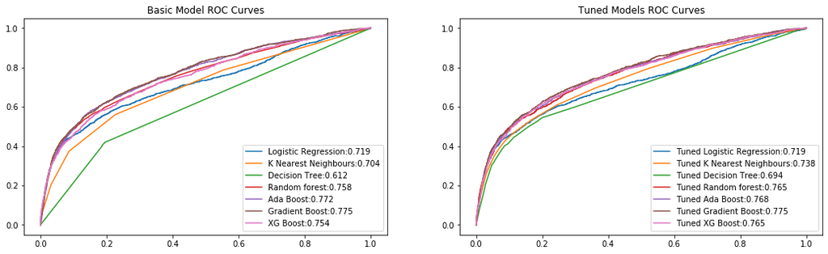

```python
fig,ax=plt.subplots(1,2,figsize=(18,5))
for i in basic_models:
    fpr,tpr,thres=roc_curve(ytest,basic_models[i].predict_proba(xtest)[:,1])
    ax[0].plot(fpr,tpr,label=str(i)+':'+str(np.round(basic_models_performance['Test ROC AUC'][i],3)))
for i in tuned_models:
    fpr,tpr,thres=roc_curve(ytest,tuned_models[i].predict_proba(xtest)[:,1])
    ax[1].plot(fpr,tpr,label=str(i)+':'+str(np.round(tuned_models_performance['Test ROC AUC'][i],3)))
ax[0].legend()
ax[0].set_title('Basic Model ROC Curves')
ax[1].legend()
ax[1].set_title('Tuned Models ROC Curves')
plt.show()
```

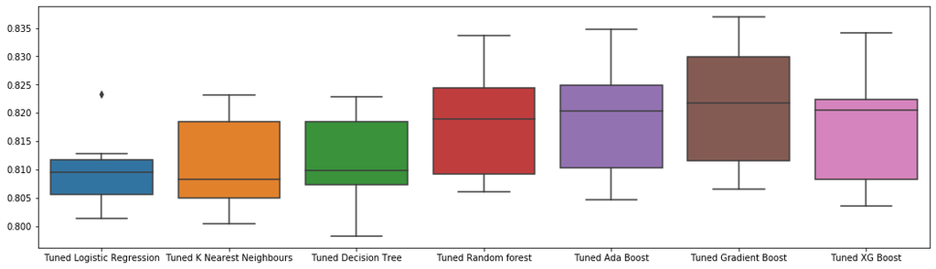

```python
plt.subplots(1,1,figsize=(18,5))
sns.boxplot(x=list(tuned_models.keys()),y=cv_list)
plt.show()
```

### Model Selection

**Tuned Gradient Boost Model seems to be the best out of the lot.**

**Gradient Boost Classifier Model seems to be coming out on top.**  
**Advantages:**

- It has the least Bias Variance.
- It gives the best fit overall.
- Gives the best test data score.
- Good Sensitivity Score.

**Limitations:**

### Feature Importance

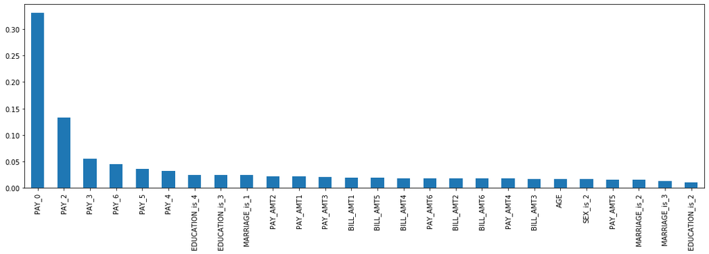

```python
pd.Series(xgbt.feature_importances_,index=x.columns).sort_values(ascending=False).plot(kind='bar',figsize=(18,5))
plt.show()
```

### Observations

- Persons who have delayed the repayment in the month of September and August seems to have defaulted more
- The column `PAY_0` has the highest significance in determining defualters which represents repayment status of September month

### Improvements

It would be better if the model gets more variables such as income level, professional experience, credit score, other loans etc. These could really classify whether the person could really pay the credit card bill.